# Bigrams

### Introduction

**Bigrams** are pairs of words that appear next to each other in a corpus.* Bigram frequencies, or how often specific words are associated with one another, provide a high-level exploration of the context in which words appear and how words are used. Bigrams often represent common phrases or multi-word expressions (e.g., *red carpet*, *iron fist*, *creative thinking*, *machine learning*, etc.). Bigram frequencies are thus a useful tool to help us confirm and discover such patterns that cannot be teased apart from the individual word frequency data alone.

*When processing the corpus to construct bigrams, we first remove all stopwords (common words like “the”, “and”, “or”, “those”, etc.) and thus bigrams indicate close but not exact word proximity relationships. For example, the phrases “day and night” and “day or night” would both result in the same bigram of “day -> night”. Thus, bigrams often represent multi-word, and not just 2-word, associations and care must be taken where stopwords could influence the interpretation.

### Word Association Network

A **word association network** displays the *most common* multi-word patterns in a corpus. Nodes (dots) are distinct words, with edges (lines) representing their association. The edge weight (how darkly it is shaded) corresponds to the frequency with which that word pair appears in the corpus. These networks help us explore the connections that specific words have with each other directly, and indirectly. For example, an association in the network represented as “sequence – action – film” means that both “action sequence” and “action film” are common bigrams in the text.

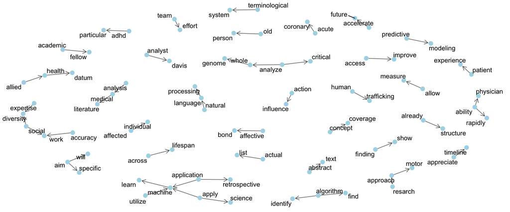

### Table of Bigrams

The **bigram frequency table** lists the most common word associations in the corpus. They are displayed in drecreasing order of frequency (the number of times that association occurs).

| Word1 | Word2 | Frequency |
| --- | --- | --- |
| machine | learn | 5 |
| health | datum | 3 |
| language | processing | 3 |
| natural | language | 3 |
| patient | experience | 3 |
| social | diversity | 3 |
| team | effort | 3 |
| concept | coverage | 2 |
| expertise | diversity | 2 |
| finding | show | 2 |
| human | trafficking | 2 |
| medical | literature | 2 |
| old | person | 2 |
| predictive | modeling | 2 |
| social | work | 2 |
| terminological | system | 2 |
| utilize | machine | 2 |
| whole | genome | 2 |
| ability | physician | 1 |
| ability | rapidly | 1 |
| abstract | text | 1 |
| academic | fellow | 1 |
| accelerate | future | 1 |
| access | improve | 1 |
| accuracy | work | 1 |
| across | lifespan | 1 |
| action | influence | 1 |
| actual | list | 1 |
| acute | coronary | 1 |
| adhd | particular | 1 |
| affected | individual | 1 |
| affective | bond | 1 |
| aim | specific | 1 |
| aim | will | 1 |
| algorithm | find | 1 |
| algorithm | identify | 1 |
| allied | health | 1 |
| allow | measure | 1 |
| already | structure | 1 |
| analysis | medical | 1 |
| analyst | davis | 1 |
| analyze | critical | 1 |
| analyze | whole | 1 |
| application | machine | 1 |
| application | retrospective | 1 |
| apply | machine | 1 |
| apply | science | 1 |
| appreciate | timeline | 1 |
| approach | motor | 1 |
| approach | resarch | 1 |

Created at the [UC Davis Data Lab](http://ds.lib.ucdavis.edu/)